# Homework 4

Nathan Bickel

2022-10-26

## Question 1

1. You are in charge of monitoring the production of nuts and bolts. Let $X$ represent the diameter in mm of a nut. You have collected data on these diameters in 2300 randomly selected nuts. You wish to use this data to construct a model for the variability in deez nuts so you can make predictions and informed decisions.
1. You wish to use your sample data to make inferences about the population variance in the diameter of a nut. Construct and interpret a 90% confidence interval for the variance in the diameter of a nut.
2. If the standard deviation in the diameter is more than .75 mm the machine must be re-calibrated. Based on your interval, does the machine need recalibration?

## Solution

We load in the data:

```r
diam_filepath = "C:\\Users\\natha\\OneDrive\\Desktop\\diam.data.csv"
diam = read.csv(diam_filepath)[,-1]
var_diam = var(diam)
n_diam = length(diam)
# Print the first ten entries to make sure it works along with n and var
cat(diam[1:10],"\nSample Variance:", var_diam, "\nNumber of Observations:", n_diam)
```

```
## 99.69607 99.15001 99.79287 100.0523 99.82713 100.9176 98.43243 99.5392 99.84717 100.0364
## Sample Variance: 0.640015
## Number of Observations: 2300
```

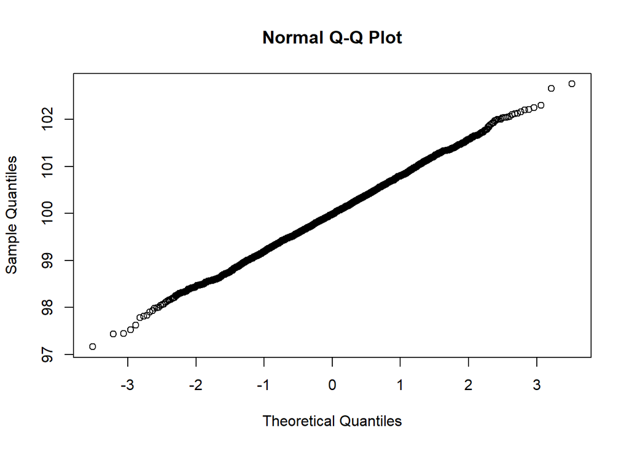

```r
qqnorm(diam)
```

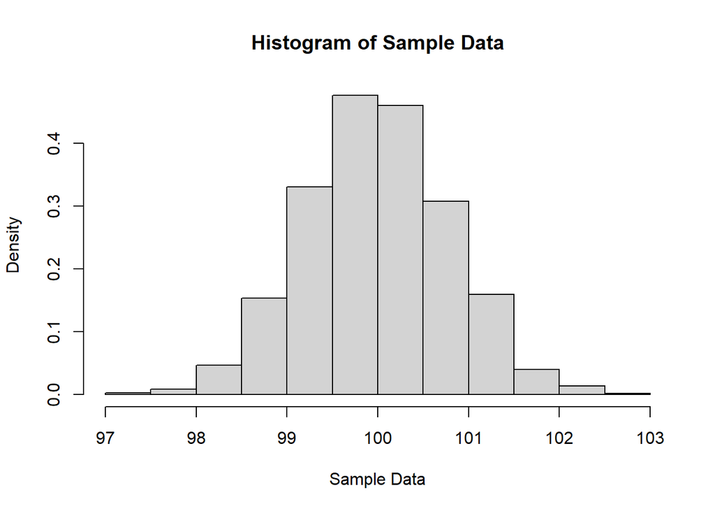

```r
hist(diam,freq=F,xlab="Sample Data",main="Histogram of Sample Data")
```

1. Since the data appear to follow a normal distribution, and we are interested in a 90% confidence interval for the variance, we can use a $\chi^2$ test. With the given parameters, this will yield an interval of
   $$\left(\frac{(2300-1)(0.640)}{\chi^2_{2300-1,0.10/2}},\frac{(2300-1)(0.640)}{\chi^2_{2300-1,1-0.10/2}}\right).$$
   This will take the following value:

```r
diam_chisq_interval = c((n_diam-1)*var_diam/qchisq(1-.05,n_diam-1,lower.tail=TRUE),(n_diam-1)*var_diam/qchisq(.05,n_diam-1))
cat("(",round(diam_chisq_interval[1],3),",",round(diam_chisq_interval[2],3),")",sep="")
```

```
## (0.61,0.672)
```

So we are 90% confident that the true population variance of deez nuts’ diameter is contained in the interval from 0.610 to 0.672.

```r
diam_stdev_interval = c(sqrt((n_diam-1)*var_diam/qchisq(1-.05,n_diam-1,lower.tail=TRUE)),sqrt((n_diam-1)*var_diam/qchisq(.05,n_diam-1)))
cat("(",round(diam_stdev_interval[1],3),",",round(diam_stdev_interval[2],3),")",sep="")
```

```
## (0.781,0.82)
```

## Question 2

2. You have collected data on 40 earthquakes. You have found that 8 of the 40 earthquakes are above a 3.0. Construct and interpret a 98% confidence interval for the proportion of earthquakes that are above a 3.0.

## Solution

We have more than 5 successes (earthquakes above 3.0) and more than 5 failures (earthquakes not above 3.0), and we have no reason to think the earthquakes wouldn’t be independent, so we can be moderately comfortable making a confidence interval for a proportion (although 10 or 15 successes would be better). We can calculate an interval:

```r
earthquake_test = prop.test(8,40,conf.level=0.98)
cat("(",round(earthquake_test$conf.int[1],3),",",round(earthquake_test$conf.int[2],3),")",sep="")
```

```
## (0.085,0.392)
```

So we are 98% confident that the true proportion of earthquakes above a 3.0 is contained in the interval from 0.085 to 0.392.

## Question 3

3. You have been tasked with collecting random soil samples at a prospective build site to ensure the location is suitable. Specifically, you will be required to compute a 99.9% confidence interval for the average strength of the soil with a margin of error of 3. It is estimated that the variance of the strength of the soil is 11.5. What is the minimum number of samples that you must collect in order to ensure that the confidence interval is constructed to the desired specifications?

## Solution

We have that a margin of error $B$ is defined by
$$B=z_{\alpha/2}\frac{\sigma}{\sqrt{n}}\Longleftrightarrow
n=\left(\frac{z_{\alpha/2}\sigma}{B}\right)^2$$
for a sample size $n$, a standard deviation $\sigma$, and $\alpha$ is 1 minus the confidence level. Since we know all of these except for $n$, we can simply use this formula:

```r
n=(qnorm((1-.999)/2))^2*11.5/3^2
cat(round(n,3))
```

```
## 13.835
```

Thus, we must take at least 14 samples in order to ensure the 99.9% interval has a margin of error less than or equal to 3. For this to be a valid procedure, the samples must be independent and the data should be assessed for normality.

## Question 4

You are in charge of selecting a new battery system to be implemented. You must choose between class A batteries and class B batteries. In order to make a decision you collect data on the lifetimes of 50 batteries of each class. You had an underling calculate the following two quantities to aid in your analysis
$$S^2_p=2.876709\quad\quad\quad\nu=74.87322.$$

1. Construct $\underline{\text{and}}$ interpret a 96% confidence interval for the difference in the mean lifetimes of the two classes of batteries. Provide support for both your choice of interval and the validity of the underlying assumptions.
2. Construct $\underline{\text{and}}$ interpret a 96% confidence interval for the ratio of the variance in the lifetimes of class A batteries to the variance in the lifetimes of class B batteries. Provide support for the validity of the underlying assumptions.
3. Based on all of your analyses, which class of batteries do you choose? Provide support for your decision.

## Solution

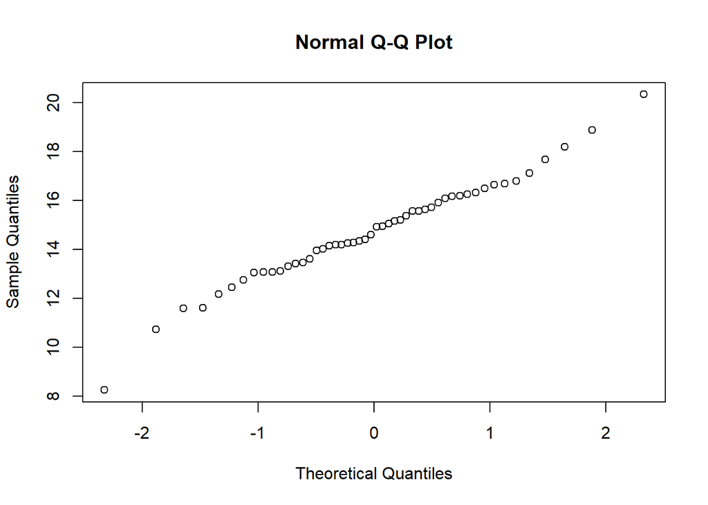

```r
abat_filepath = "C:\\Users\\natha\\OneDrive\\Desktop\\a.batteries.csv"
abat = read.csv(abat_filepath)[,-1]
bbat_filepath = "C:\\Users\\natha\\OneDrive\\Desktop\\b.batteries.csv"
bbat = read.csv(bbat_filepath)[,-1]
qqnorm(abat)
```

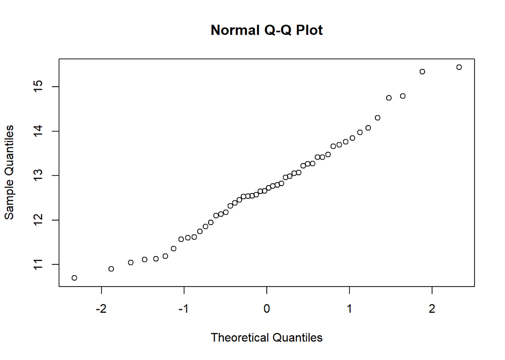

```r
qqnorm(bbat)
```

```r
avar = var(abat)
bvar = var(bbat)
cat("Battery A Variance: ", avar, "\nBattery B Variance: ", bvar, sep="")
```

```
## Battery A Variance: 4.475494
## Battery B Variance: 1.277923
```

The data appear approximately normal, we have no reason to think the two samples were dependent, and the variances are clearly different.

1. Thus, we use a difference of means t-test, which gives the following interval:

```r
battery_test = t.test(abat, bbat, conf.level=0.96,var.equal=FALSE)
cat("(",round(battery_test$conf.int[1],3),",",round(battery_test$conf.int[2],3),")",sep="")
```

```
## (1.274,2.692)
```

So we are 96% confident that the true difference between the mean lifetime of Battery A and the mean lifetime of Battery B is between 1.274 and 2.692 time units.

2. We can use an F distribution to generate this confidence interval:

```r
F.lower = qf(0.02,length(abat)-1,length(bbat)-1)
F.upper = qf(0.98,length(abat)-1,length(bbat)-1)
F.interval = c((avar/bvar)*F.lower,(avar/bvar)*F.upper)
cat("(",round(F.interval[1],3),",",round(F.interval[2]),")",sep="")
```

```
## (1.934,6)
```

So we are 96% confident that the true ratio of the variance of the lifetime of Battery A to the variance of the lifetime of Battery B is between 1.934 and 6.000.

3. We have evidence that the mean lifetime of battery A is greater than the mean lifetime of battery B because the interval is entirely positive. We also have evidence that battery A has a greater variance, because the F interval is entirely above 1. While a high mean and low variance would be preferable, I would choose Battery A because it seems that having a higher mean lifetime is somewhat more important than having a more consistently low lifetime.

## Question 5

5. You have collected data on the processing speed for 20 super computers, both before and after a newly designed chip was implemented. Construct and interpret an 80% confidence interval for the difference between the average computing speed before and after the implementation of the new chip. Provide support for both your choice of interval and the validity of the underlying assumptions.

## Solution

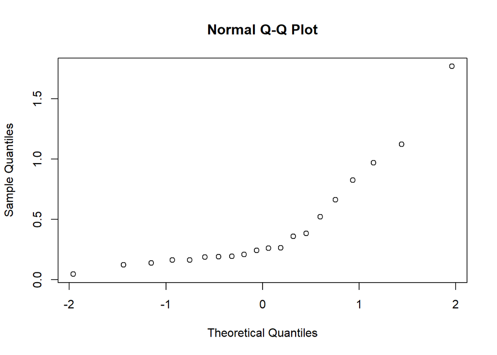

```r
computer_filepath = "C:\\Users\\natha\\OneDrive\\Desktop\\computer.csv"
computer = read.csv(computer_filepath)[,-1]
qqnorm(computer)
```

The data barely follows a normal distribution, if at all. However, with 20 observations, we have nearly enough data for the central limit theorem to hold, so we can cautiously use a t test matched pairs interval (the pairs are the computer before and after the new chip) to get the following interval:

```r
computer_test = t.test(computer, conf.level=.8)
cat("(",round(computer_test$conf.int[1],3),",",round(computer_test$conf.int[2],3),")",sep="")
```

```
## (0.312,0.569)
```

So we are 80% confident that the difference between the speed before and after the chip is between 0.312 and 0.569 units. So it seems that the chip made a difference, but again we should only tenuously trust this result because it may not be robust enough to the seeming violation of normality.

## Question 6

6. You are comparing the quality of a certain part that is produced by two different manufacturers. You sample 1000 parts from each manufacturer. You find 4 defectives in the parts from the first manufacturer and 20 defectives in the parts from the second manufacturer.
1. Construct and interpret a 98% confidence interval for the difference between the population proportions of defective parts for the two manufacturers.
2. Do we have evidence that the quality of one manufacturer’s parts is superior?

## Solution.

1. We would like to have more defectives than 4 from the first manufacturer, so that may cast doubt on the interval. However, we can use a two proportion interval:

```r
part_test = prop.test(c(4,20),c(1000,1000),conf.level=0.98)
cat("(",round(part_test$conf.int[1],3),",",round(part_test$conf.int[2],3),")",sep="")
```

```
## (-0.028,-0.004)
```

So we are 98% that the true difference in proportions between the first manufacturer and second manufacturer is between -0.028 and -0.004.

2. We technically have evidence that the true proportion of defects from the first manufacturer is lower than that of the second manufacturer. Since we want fewer defects, the first manufacturer seems to be superior. However, as noted, the validity of the interval is rather dubious because of how few defects the first manufacturer have, and 0 is barely outside the interval so the evidence is not particularly compelling.